# Pertemuan 1 - Pemulusan

Fadly Mochammad Taufiq

# 1 Library / Packages

```r
library("forecast")
```

```r
library("graphics")
library("TTR")
library("TSA")
```

# 2 Impor Data

```r
data_minyak <- read.csv("https://raw.githubusercontent.com/imomenujung/MPDW/main/Pertemuan%201/Data%20Minyak.csv", sep = ";")
data_minyak
```

```
##     Period Minyak_Goreng
## 1        1         15250
## 2        2         15250
## 3        3         15300
## 4        4         15250
## 5        5         15300
## 6        6         15350
## 7        7         15250
## 8        8         15300
## 9        9         15600
## 10      10         15650
## 11      11         15900
## 12      12         15950
## 13      13         16200
## 14      14         16200
```

[output cut: 106 more lines]

# 3 Eksplorasi Data

Melihat data menggunakan fungsi `View()`, struktur data menggunakan fungsi `str()`, dan dimensi data menggunakan fungsi `dim()`.

```r
str(data_minyak)
```

```
## 'data.frame':    120 obs. of  2 variables:
##  $ Period       : int  1 2 3 4 5 6 7 8 9 10 ...
##  $ Minyak_Goreng: int  15250 15250 15300 15250 15300 15350 15250 15300 15600 15650 ...
```

```r
dim(data_minyak)
```

```
## [1] 120   2
```

#mengubah data menjadi Time Series

```r
harga_minyak <- ts(data_minyak$`Minyak_Goreng`)
```

#melihat ringkasan data

```r
summary(harga_minyak)
```

```
##    Min. 1st Qu.  Median    Mean 3rd Qu.    Max.
##   15250   17650   18650   18690   19362   23850
```

#Membuat plot deret waktu

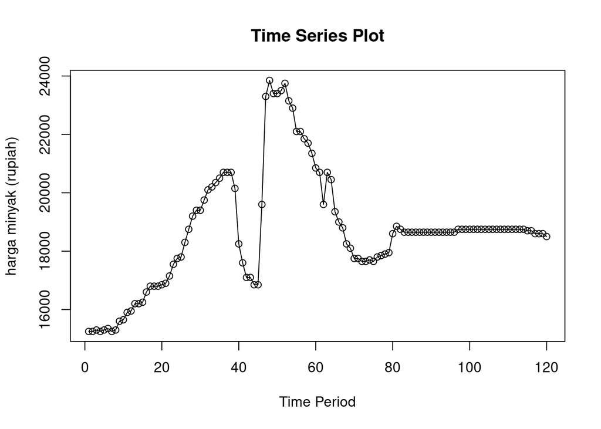

```r
ts.plot(harga_minyak, xlab="Time Period", ylab="harga minyak (rupiah)",
         main = "Time Series Plot")
points(harga_minyak)
```

#membagi data latih dan data uji Pembagian data latih dan data uji dilakukan dengan perbandingan 80% data latih dan 20% data uji.

```r
training_ma <- data_minyak[1:96,]
testing_ma <- data_minyak[97:120,]
train_ma.ts <- ts(training_ma$`Minyak_Goreng`)
test_ma.ts <- ts(testing_ma$`Minyak_Goreng`)
```

#Eksplorasi data

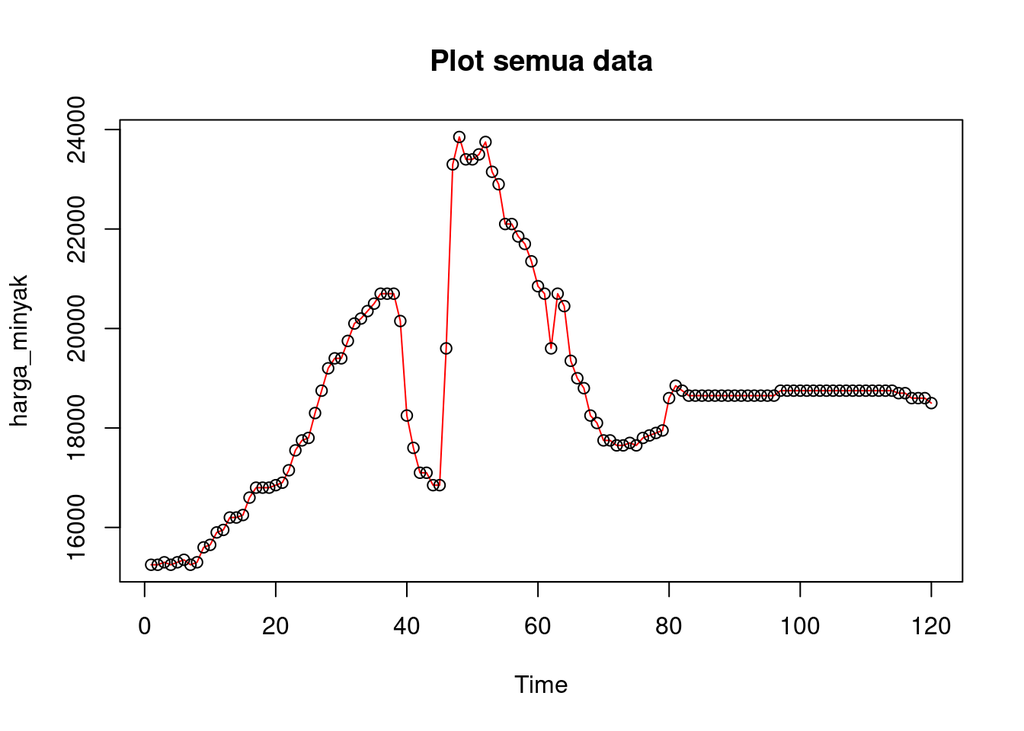

```r
#eksplorasi keseluruhan data
plot(harga_minyak, col="red",main="Plot semua data")
points(harga_minyak)
```

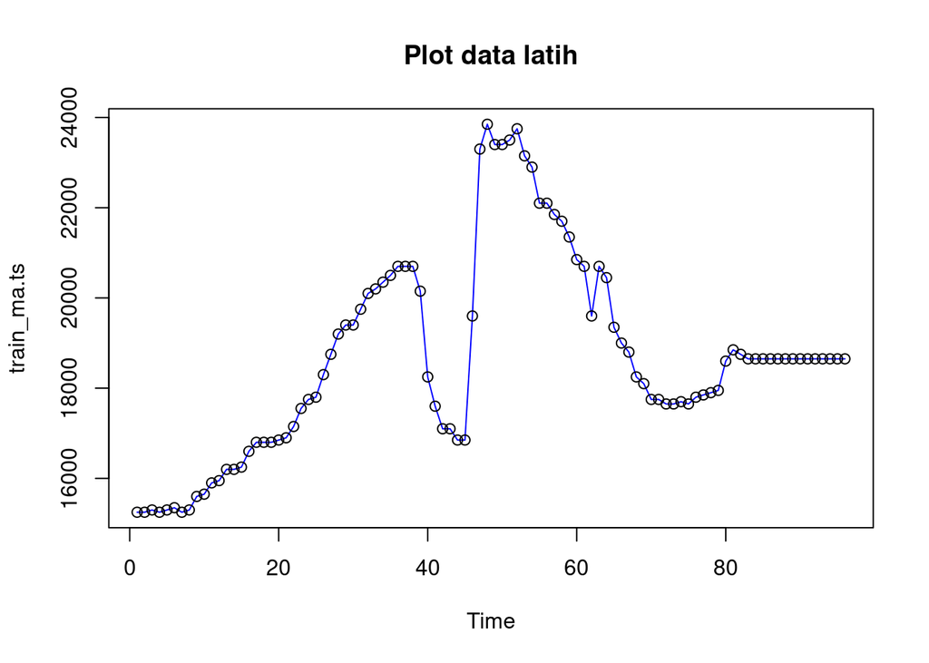

```r
#eksplorasi data latih
plot(train_ma.ts, col="blue",main="Plot data latih")
points(train_ma.ts)
```

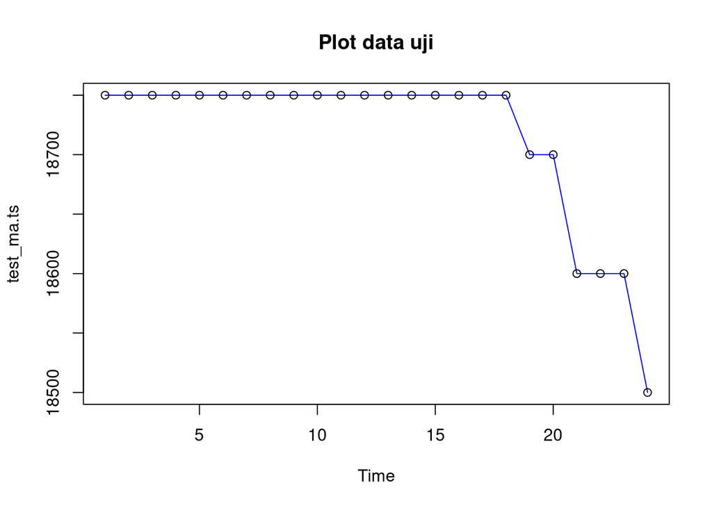

```r
#eksplorasi data uji
plot(test_ma.ts, col="blue",main="Plot data uji")
points(test_ma.ts)
```

#Eksplorasi data menggunakan ggplot

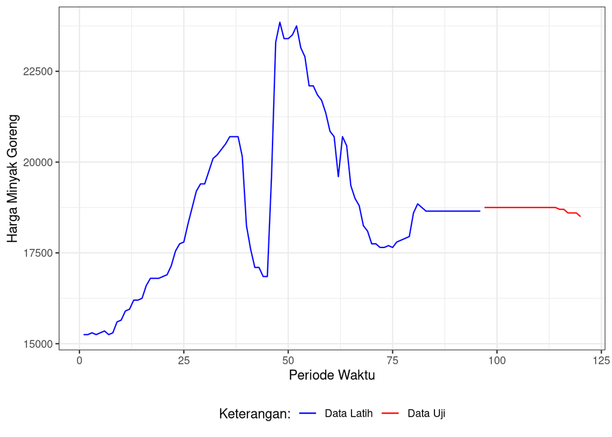

```r
library(ggplot2)
ggplot() +
  geom_line(data = training_ma, aes(x = Period , y = Minyak_Goreng, col = "Data Latih")) +
  geom_line(data = testing_ma, aes(x = Period, y = Minyak_Goreng, col = "Data Uji")) +
  labs(x = "Periode Waktu", y = "Harga Minyak Goreng", color = "Legend") +
  scale_colour_manual(name="Keterangan:", breaks = c("Data Latih", "Data Uji"),
                      values = c("blue", "red")) +
  theme_bw() + theme(legend.position = "bottom",
                     plot.caption = element_text(hjust=0.5, size=12))
```

#Single Moving Average (SMA)

Ide dasar dari Single Moving Average (SMA) adalah data suatu periode dipengaruhi oleh data periode sebelumnya. Metode pemulusan ini cocok digunakan untuk pola data stasioner atau konstan. Prinsip dasar metode pemulusan ini adalah data pemulusan pada periode ke-t merupakan rata rata dari m buah data pada periode ke-t hingga periode ke (t-m+1). Data pemulusan pada periode ke-t selanjutnya digunakan sebagai nilai peramalan pada periode ke t+1

Pemulusan menggunakan metode SMA dilakukan dengan fungsi `SMA()`. Dalam hal ini akan dilakukan pemulusan dengan parameter `m=4`.

```r
data.sma<-SMA(train_ma.ts, n=4)
data.sma
```

```
## Time Series:
## Start = 1
## End = 96
## Frequency = 1
##  [1]      NA      NA      NA 15262.5 15275.0 15300.0 15287.5 15300.0 15375.0
## [10] 15450.0 15612.5 15775.0 15925.0 16062.5 16150.0 16312.5 16462.5 16612.5
## [19] 16750.0 16812.5 16837.5 16925.0 17112.5 17337.5 17562.5 17850.0 18150.0
## [28] 18512.5 18912.5 19187.5 19437.5 19662.5 19862.5 20100.0 20287.5 20437.5
## [37] 20562.5 20650.0 20562.5 19950.0 19175.0 18275.0 17512.5 17162.5 16975.0
## [46] 17600.0 19150.0 20900.0 22537.5 23487.5 23537.5 23512.5 23450.0 23325.0
## [55] 22975.0 22562.5 22237.5 21937.5 21750.0 21437.5 21150.0 20625.0 20462.5
## [64] 20362.5 20025.0 19875.0 19400.0 18850.0 18537.5 18225.0 17962.5 17812.5
## [73] 17700.0 17687.5 17662.5 17700.0 17750.0 17800.0 17875.0 18075.0 18325.0
## [82] 18537.5 18712.5 18725.0 18675.0 18650.0 18650.0 18650.0 18650.0 18650.0
## [91] 18650.0 18650.0 18650.0 18650.0 18650.0 18650.0
```

Data pemulusan pada periode ke-t selanjutnya digunakan sebagai nilai peramalan pada periode ke t+1 sehingga hasil peramalan 1 periode kedepan adalah sebagai berikut.

```r
data.ramal<-c(NA,data.sma)
data.ramal #forecast 1 periode ke depan
```

```
##  [1]      NA      NA      NA      NA 15262.5 15275.0 15300.0 15287.5 15300.0
## [10] 15375.0 15450.0 15612.5 15775.0 15925.0 16062.5 16150.0 16312.5 16462.5
## [19] 16612.5 16750.0 16812.5 16837.5 16925.0 17112.5 17337.5 17562.5 17850.0
## [28] 18150.0 18512.5 18912.5 19187.5 19437.5 19662.5 19862.5 20100.0 20287.5
## [37] 20437.5 20562.5 20650.0 20562.5 19950.0 19175.0 18275.0 17512.5 17162.5
## [46] 16975.0 17600.0 19150.0 20900.0 22537.5 23487.5 23537.5 23512.5 23450.0
## [55] 23325.0 22975.0 22562.5 22237.5 21937.5 21750.0 21437.5 21150.0 20625.0
## [64] 20462.5 20362.5 20025.0 19875.0 19400.0 18850.0 18537.5 18225.0 17962.5
## [73] 17812.5 17700.0 17687.5 17662.5 17700.0 17750.0 17800.0 17875.0 18075.0
## [82] 18325.0 18537.5 18712.5 18725.0 18675.0 18650.0 18650.0 18650.0 18650.0
## [91] 18650.0 18650.0 18650.0 18650.0 18650.0 18650.0 18650.0
```

Selanjutnya akan dilakukan peramalan sejumlah data uji yaitu 24 periode. Pada metode SMA, hasil peramalan 24 periode ke depan akan bernilai sama dengan hasil peramalan 1 periode kedepan. Dalam hal ini akan dilakukan pengguabungan data aktual train, data hasil pemulusan dan data hasil ramalan 24 periode kedepan.

```r
data.gab<-cbind(aktual=c(train_ma.ts,rep(NA,24)),pemulusan=c(data.sma,rep(NA,24)),ramalan=c(data.ramal,rep(data.ramal[length(data.ramal)],23)))
data.gab #forecast 24 periode ke depan
```

```
##        aktual pemulusan ramalan
##   [1,]  15250        NA      NA
##   [2,]  15250        NA      NA
##   [3,]  15300        NA      NA
##   [4,]  15250   15262.5      NA
##   [5,]  15300   15275.0 15262.5
##   [6,]  15350   15300.0 15275.0
##   [7,]  15250   15287.5 15300.0
##   [8,]  15300   15300.0 15287.5
##   [9,]  15600   15375.0 15300.0
##  [10,]  15650   15450.0 15375.0
##  [11,]  15900   15612.5 15450.0
##  [12,]  15950   15775.0 15612.5
##  [13,]  16200   15925.0 15775.0
##  [14,]  16200   16062.5 15925.0
```

[output cut: 106 more lines]

Adapun plot data deret waktu dari hasil peramalan yang dilakukan adalah sebagai berikut.

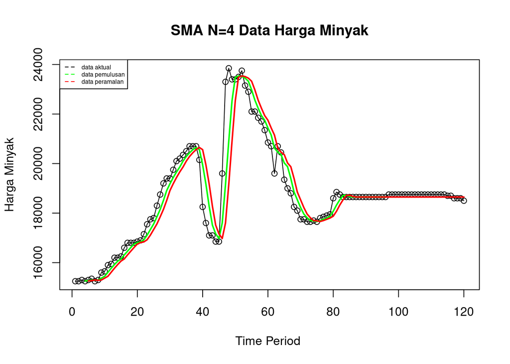

```r
ts.plot(harga_minyak, xlab="Time Period ", ylab="Harga Minyak", main= "SMA N=4 Data Harga Minyak")
points(harga_minyak)
lines(data.gab[,2],col="green",lwd=2)
lines(data.gab[,3],col="red",lwd=2)
legend("topleft",c("data aktual","data pemulusan","data peramalan"), lty=8, col=c("black","green","red"), cex=0.5)
```

Selanjutnya perhitungan akurasi dilakukan dengan ukuran akurasi *Sum Squares Error* (SSE), *Mean Square Error* (MSE) dan *Mean Absolute Percentage Error* (MAPE). Perhitungan akurasi dilakukan baik pada data latih maupun pada data uji.

```r
error_train.sma = train_ma.ts-data.ramal[1:length(train_ma.ts)]
SSE_train.sma = sum(error_train.sma[5:length(train_ma.ts)]^2)
MSE_train.sma = mean(error_train.sma[5:length(train_ma.ts)]^2)
MAPE_train.sma = mean(abs((error_train.sma[5:length(train_ma.ts)]/train_ma.ts[5:length(train_ma.ts)])*100))

akurasi_train.sma <- matrix(c(SSE_train.sma, MSE_train.sma, MAPE_train.sma))
row.names(akurasi_train.sma)<- c("SSE", "MSE", "MAPE")
colnames(akurasi_train.sma) <- c("Akurasi m = 4")
akurasi_train.sma
```

```
##      Akurasi m = 4
## SSE   1.086408e+08
## MSE   1.180878e+06
## MAPE  3.166540e+00
```

#Akurasi data Uji

```r
#Menghitung nilai keakuratan data uji
error_test.sma = test_ma.ts-data.gab[97:120,3]
SSE_test.sma = sum(error_test.sma^2)
MSE_test.sma = mean(error_test.sma^2)
MAPE_test.sma = mean(abs((error_test.sma/test_ma.ts*100)))

akurasi_test.sma <- matrix(c(SSE_test.sma, MSE_test.sma, MAPE_test.sma))
row.names(akurasi_test.sma)<- c("SSE", "MSE", "MAPE")
colnames(akurasi_test.sma) <- c("Akurasi m = 4")
akurasi_test.sma
```

```
##      Akurasi m = 4
## SSE   2.150000e+05
## MSE   8.958333e+03
## MAPE  4.896676e-01
```

## 3.1 Double Moving Average (DMA)

Metode pemulusan Double Moving Average (DMA) pada dasarnya mirip dengan SMA. Namun demikian, metode ini lebih cocok digunakan untuk pola data trend. Proses pemulusan dengan rata rata dalam metode ini dilakukan sebanyak 2 kali.

```r
dma <- SMA(data.sma, n = 4)
At <- 2*data.sma - dma
Bt <- 2/(4-1)*(data.sma - dma)
data.dma<- At+Bt
data.ramal2<- c(NA, data.dma)

t = 1:24
f = c()

for (i in t) {
  f[i] = At[length(At)] + Bt[length(Bt)]*(i)
}

data.gab2 <- cbind(aktual = c(train_ma.ts,rep(NA,24)), pemulusan1 = c(data.sma,rep(NA,24)),pemulusan2 = c(data.dma, rep(NA,24)),At = c(At, rep(NA,24)), Bt = c(Bt,rep(NA,24)),ramalan = c(data.ramal2, f[-1]))
data.gab2
```

```
##        aktual pemulusan1 pemulusan2       At          Bt  ramalan
##   [1,]  15250         NA         NA       NA          NA       NA
##   [2,]  15250         NA         NA       NA          NA       NA
##   [3,]  15300         NA         NA       NA          NA       NA
##   [4,]  15250    15262.5         NA       NA          NA       NA
##   [5,]  15300    15275.0         NA       NA          NA       NA
##   [6,]  15350    15300.0         NA       NA          NA       NA
##   [7,]  15250    15287.5   15297.92 15293.75    4.166667       NA
##   [8,]  15300    15300.0   15315.62 15309.38    6.250000 15297.92
##   [9,]  15600    15375.0   15473.96 15434.38   39.583333 15315.62
##  [10,]  15650    15450.0   15611.46 15546.88   64.583333 15473.96
##  [11,]  15900    15612.5   15909.38 15790.62  118.750000 15611.46
##  [12,]  15950    15775.0   16144.79 15996.88  147.916667 15909.38
##  [13,]  16200    15925.0   16315.62 16159.38  156.250000 16144.79
##  [14,]  16200    16062.5   16427.08 16281.25  145.833333 16315.62
```

[output cut: 106 more lines]

#Visualisasi data DMA

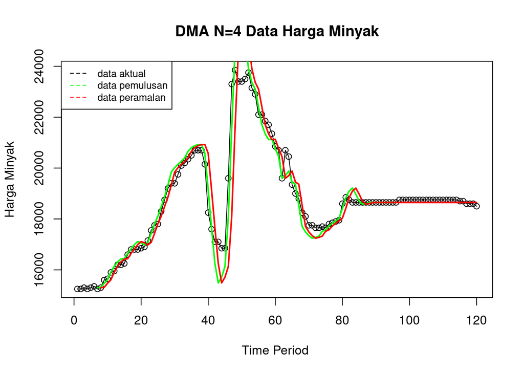

```r
ts.plot(harga_minyak, xlab="Time Period ", ylab="Harga Minyak", main= "DMA N=4 Data Harga Minyak")
points(harga_minyak)
lines(data.gab2[,3],col="green",lwd=2)
lines(data.gab2[,6],col="red",lwd=2)
legend("topleft",c("data aktual","data pemulusan","data peramalan"), lty=8, col=c("black","green","red"), cex=0.8)
```

#Menghitung nilai keakuratan data latih

```r
error_train.dma = train_ma.ts-data.ramal2[1:length(train_ma.ts)]
SSE_train.dma = sum(error_train.dma[8:length(train_ma.ts)]^2)
MSE_train.dma = mean(error_train.dma[8:length(train_ma.ts)]^2)
MAPE_train.dma = mean(abs((error_train.dma[8:length(train_ma.ts)]/train_ma.ts[8:length(train_ma.ts)])*100))

akurasi_train.dma <- matrix(c(SSE_train.dma, MSE_train.dma, MAPE_train.dma))
row.names(akurasi_train.dma)<- c("SSE", "MSE", "MAPE")
colnames(akurasi_train.dma) <- c("Akurasi m = 4")
akurasi_train.dma
```

```
##      Akurasi m = 4
## SSE   9.113334e+07
## MSE   1.023970e+06
## MAPE  2.661248e+00
```

#Menghitung nilai keakuratan data uji

```r
error_test.dma = test_ma.ts-data.gab2[97:120,6]
SSE_test.dma = sum(error_test.dma^2)
MSE_test.dma = mean(error_test.dma^2)
MAPE_test.dma = mean(abs((error_test.dma/test_ma.ts*100)))

akurasi_test.dma <- matrix(c(SSE_test.dma, MSE_test.dma, MAPE_test.dma))
row.names(akurasi_test.dma)<- c("SSE", "MSE", "MAPE")
colnames(akurasi_test.dma) <- c("Akurasi m = 4")
akurasi_test.dma
```

```
##      Akurasi m = 4
## SSE   2.150000e+05
## MSE   8.958333e+03
## MAPE  4.896676e-01
```

# 4 Single Exponential Smoothing

## 4.1 Pembagian Data

Pembagian data latih dan data uji dilakukan dengan perbandingan 80% data latih dan 20% data uji.

```r
#membagi training dan testing
training<-data_minyak[1:96,]
testing<-data_minyak[97:120,]
train.ts <- ts(training$Minyak_Goreng)
test.ts <- ts(testing$Minyak_Goreng)
```

#Eksplorasi Data

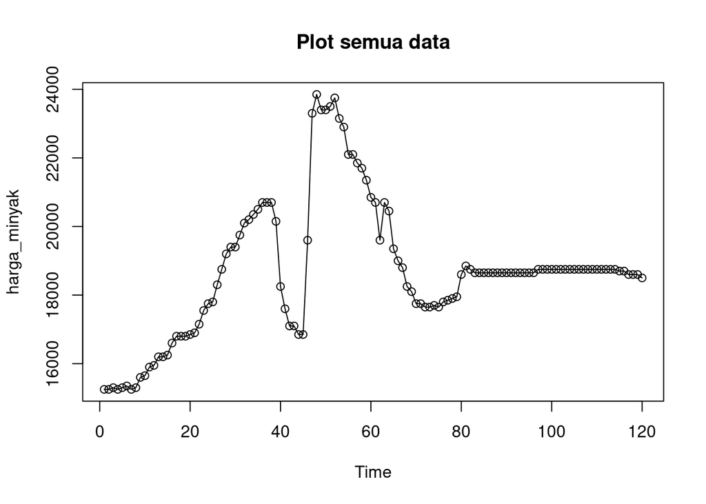

```r
#eksplorasi data
plot(harga_minyak, col="black",main="Plot semua data")
points(harga_minyak)
```

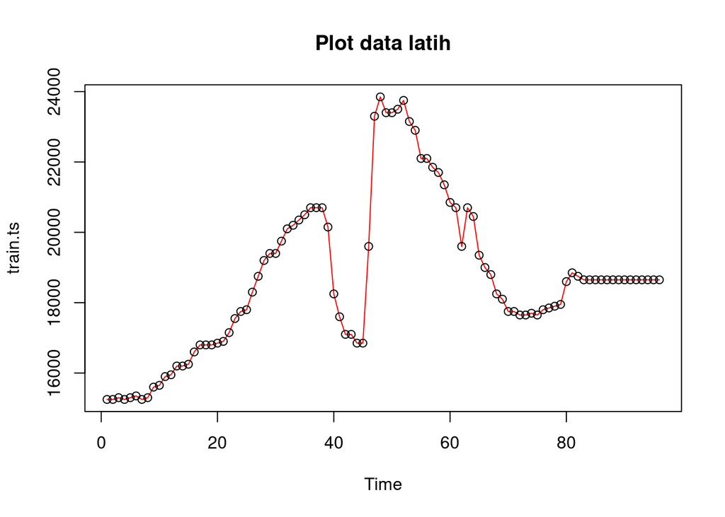

```r
plot(train.ts, col="red",main="Plot data latih")
points(train.ts)
```

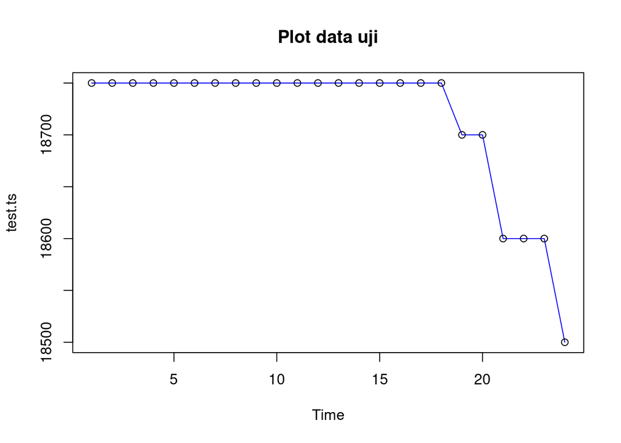

```r
plot(test.ts, col="blue",main="Plot data uji")
points(test.ts)
```

#Eksplorasi dengan GGplot

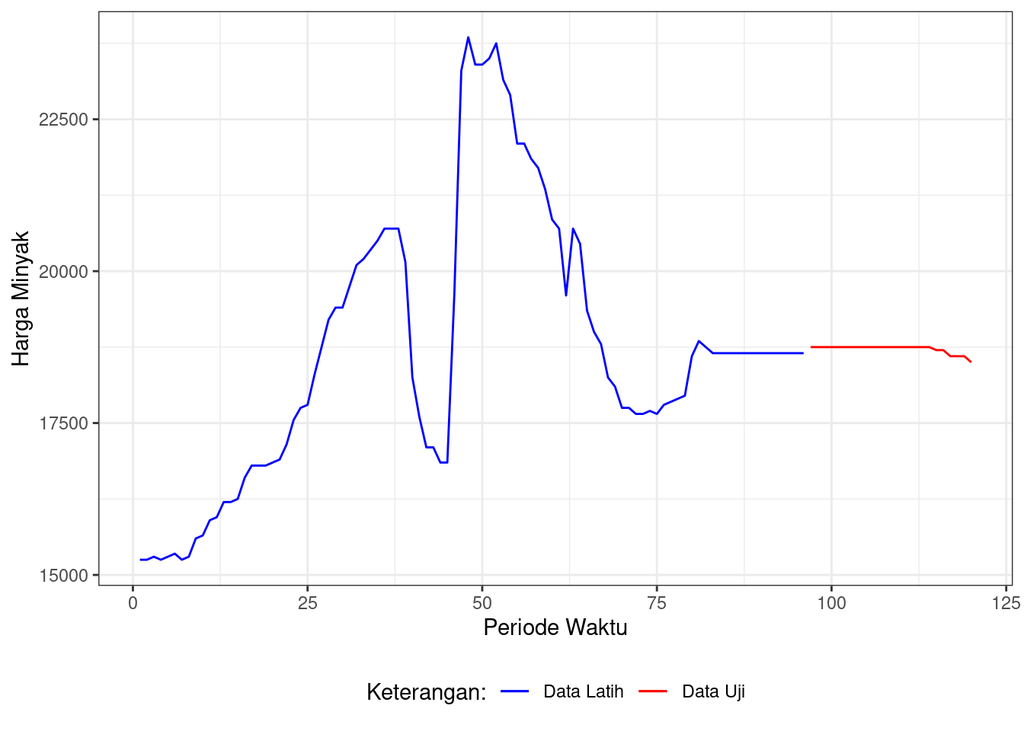

```r
library(ggplot2)
ggplot() +
  geom_line(data = training, aes(x = Period, y = Minyak_Goreng, col = "Data Latih")) +
  geom_line(data = testing, aes(x = Period, y = Minyak_Goreng, col = "Data Uji")) +
  labs(x = "Periode Waktu", y = "Harga Minyak", color = "Legend") +
  scale_colour_manual(name="Keterangan:", breaks = c("Data Latih", "Data Uji"),
                      values = c("blue", "red")) +
  theme_bw() + theme(legend.position = "bottom",
                     plot.caption = element_text(hjust=0.5, size=12))
```

## 4.2 SES

Single Exponential Smoothing merupakan metode pemulusan yang tepat digunakan untuk data dengan pola stasioner atau konstan.

Nilai pemulusan pada periode ke-t didapat dari persamaan:

$$\tilde{y}_T=\lambda y_t+(1-\lambda)\tilde{y}_{T-1}$$

Nilai parameter $\lambda$ adalah nilai antara 0 dan 1.

Nilai pemulusan periode ke-t bertindak sebagai nilai ramalan pada periode ke-$(T+\tau)$.

$$\tilde{y}_{T+\tau}(T)=\tilde{y}_T$$

Pemulusan dengan metode SES dapat dilakukan dengan dua fungsi dari *packages* berbeda, yaitu (1) fungsi `ses()` dari *packages* `forecast` dan (2) fungsi `HoltWinters` dari *packages* `stats` .

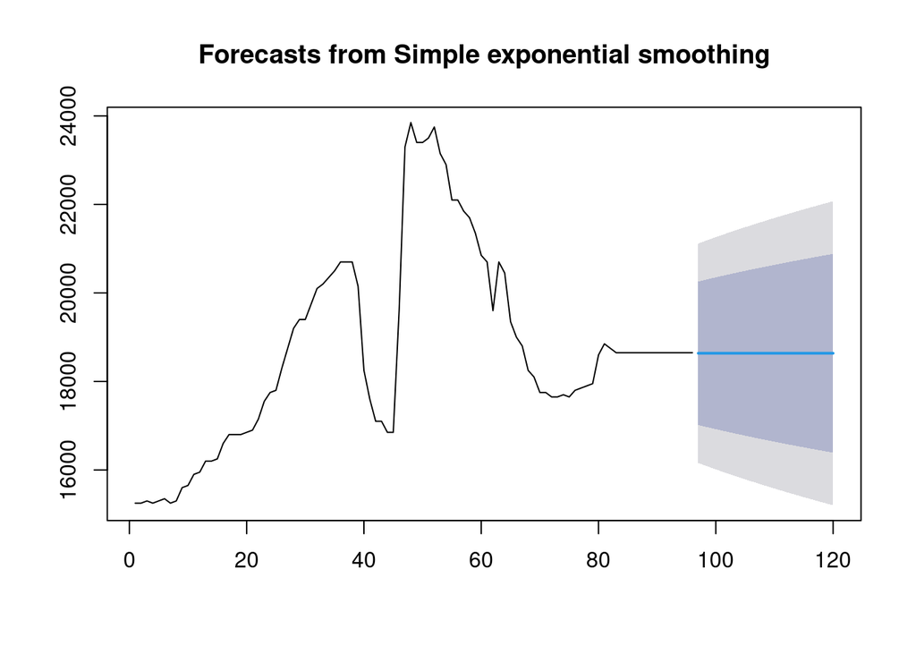

```r
#Cara 1 (fungsi ses)
ses.1 <- ses(train.ts, h = 24, alpha = 0.2)
plot(ses.1)
```

```r
ses.1
```

```
##     Point Forecast    Lo 80    Hi 80    Lo 95    Hi 95
##  97       18636.95 17016.04 20257.87 16157.98 21115.93
##  98       18636.95 16983.94 20289.97 16108.89 21165.02
##  99       18636.95 16952.45 20321.46 16060.73 21213.18
## 100       18636.95 16921.54 20352.37 16013.46 21260.45
## 101       18636.95 16891.18 20382.73 15967.02 21306.89
## 102       18636.95 16861.33 20412.58 15921.38 21352.53
## 103       18636.95 16831.98 20441.93 15876.49 21397.42
## 104       18636.95 16803.10 20470.81 15832.32 21441.59
## 105       18636.95 16774.67 20499.24 15788.83 21485.08
## 106       18636.95 16746.66 20527.25 15746.00 21527.91
## 107       18636.95 16719.06 20554.85 15703.79 21570.12
## 108       18636.95 16691.86 20582.05 15662.19 21611.72
## 109       18636.95 16665.03 20608.88 15621.15 21652.76
## 110       18636.95 16638.56 20635.35 15580.67 21693.24
## 111       18636.95 16612.43 20661.47 15540.72 21733.19
## 112       18636.95 16586.64 20687.27 15501.27 21772.64
## 113       18636.95 16561.17 20712.74 15462.32 21811.59
## 114       18636.95 16536.01 20737.90 15423.84 21850.07
## 115       18636.95 16511.15 20762.76 15385.81 21888.10
## 116       18636.95 16486.57 20787.34 15348.22 21925.68
## 117       18636.95 16462.27 20811.64 15311.06 21962.85
## 118       18636.95 16438.24 20835.67 15274.31 21999.60
## 119       18636.95 16414.47 20859.44 15237.96 22035.95
## 120       18636.95 16390.95 20882.96 15201.99 22071.92
```

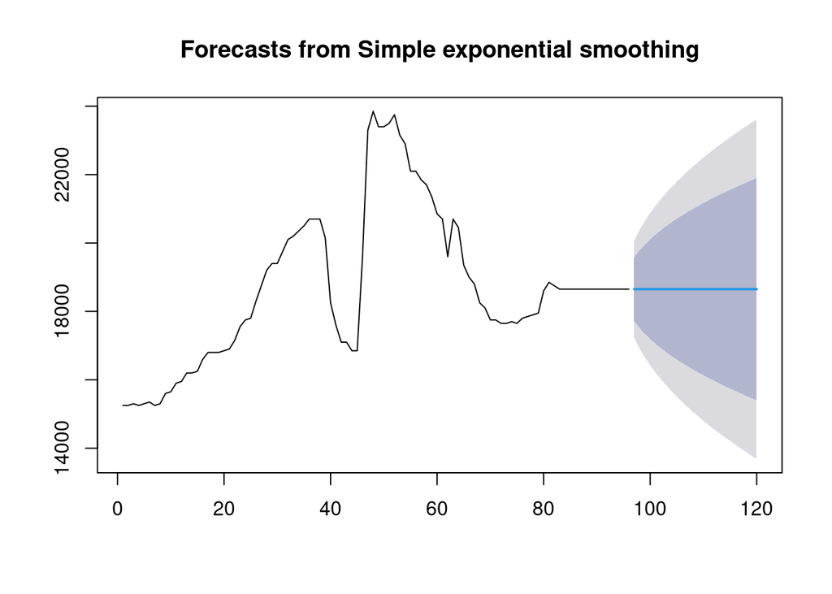

```r
ses.2<- ses(train.ts, h = 24, alpha = 0.7)
plot(ses.2)
```

```r
ses.2
```

```
##     Point Forecast    Lo 80    Hi 80    Lo 95    Hi 95
##  97          18650 17723.55 19576.45 17233.12 20066.88
##  98          18650 17519.12 19780.88 16920.47 20379.53
##  99          18650 17346.37 19953.63 16656.27 20643.73
## 100          18650 17193.97 20106.03 16423.19 20876.81
## 101          18650 17056.08 20243.92 16212.30 21087.70
## 102          18650 16929.20 20370.80 16018.26 21281.74
## 103          18650 16811.05 20488.95 15837.57 21462.43
## 104          18650 16700.05 20599.95 15667.81 21632.19
## 105          18650 16595.03 20704.97 15507.20 21792.80
## 106          18650 16495.13 20804.87 15354.41 21945.59
## 107          18650 16399.66 20900.34 15208.40 22091.60
## 108          18650 16308.08 20991.92 15068.34 22231.66
## 109          18650 16219.94 21080.06 14933.55 22366.45
## 110          18650 16134.90 21165.10 14803.48 22496.52
## 111          18650 16052.63 21247.37 14677.67 22622.33
## 112          18650 15972.90 21327.10 14555.72 22744.28
## 113          18650 15895.47 21404.53 14437.30 22862.70
## 114          18650 15820.15 21479.85 14322.12 22977.88
## 115          18650 15746.79 21553.21 14209.93 23090.07
## 116          18650 15675.24 21624.76 14100.50 23199.50
## 117          18650 15605.37 21694.63 13993.65 23306.35
## 118          18650 15537.07 21762.93 13889.19 23410.81
## 119          18650 15470.24 21829.76 13786.97 23513.03
## 120          18650 15404.78 21895.22 13686.86 23613.14
```

Untuk mendapatkan gambar hasil pemulusan pada data latih dengan fungsi `ses()` , perlu digunakan fungsi `autoplot()` dan `autolayer()` dari *library packages* `ggplot2` .

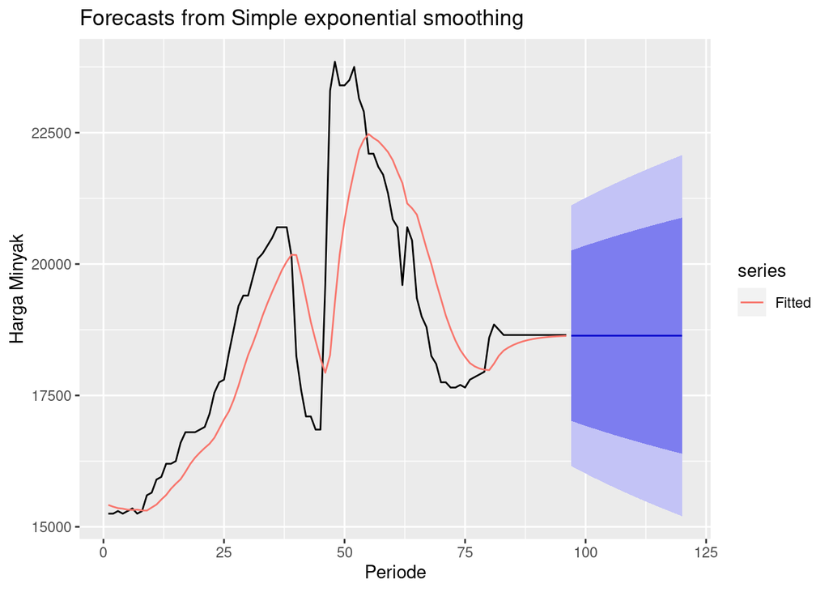

```r
autoplot(ses.1) +
  autolayer(fitted(ses.1), series="Fitted") +
  ylab("Harga Minyak") + xlab("Periode")
```

Pada fungsi `ses()` , terdapat beberapa argumen yang umum digunakan, yaitu nilia `y` , `gamma` , `beta` , `alpha` , dan `h` .

Nilai `y` adalah nilai data deret waktu, `gamma` adalah parameter pemulusan untuk komponen musiman, `beta` adalah parameter pemulusan untuk tren, dan `alpha` adalah parameter pemulusan untuk stasioner, serta `h` adalah banyaknya periode yang akan diramalkan.

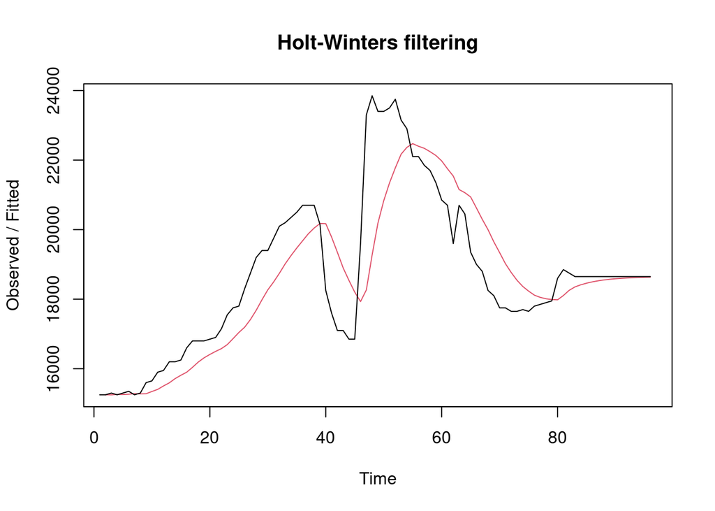

```r
#Cara 2 (fungsi Holtwinter)
ses1<- HoltWinters(train.ts, gamma = FALSE, beta = FALSE, alpha = 0.2)
plot(ses1)
```

```r
#ramalan
ramalan1<- forecast(ses1, h=24)
ramalan1
```

```
##     Point Forecast    Lo 80    Hi 80    Lo 95    Hi 95
##  97       18636.95 17031.97 20241.93 16182.35 21091.56
##  98       18636.95 17000.19 20273.72 16133.74 21140.17
##  99       18636.95 16969.01 20304.90 16086.05 21187.86
## 100       18636.95 16938.40 20335.51 16039.24 21234.66
## 101       18636.95 16908.34 20365.57 15993.26 21280.65
## 102       18636.95 16878.79 20395.12 15948.07 21325.84
## 103       18636.95 16849.72 20424.18 15903.62 21370.29
## 104       18636.95 16821.13 20452.78 15859.89 21414.02
## 105       18636.95 16792.97 20480.94 15816.83 21457.08
## 106       18636.95 16765.24 20508.67 15774.42 21499.49
## 107       18636.95 16737.92 20535.99 15732.63 21541.28
## 108       18636.95 16710.98 20562.93 15691.43 21582.48
## 109       18636.95 16684.41 20589.50 15650.80 21623.11
## 110       18636.95 16658.20 20615.71 15610.71 21663.20
## 111       18636.95 16632.33 20641.57 15571.15 21702.76
## 112       18636.95 16606.80 20667.11 15532.10 21741.81
## 113       18636.95 16581.58 20692.33 15493.53 21780.38
## 114       18636.95 16556.66 20717.25 15455.42 21818.49
## 115       18636.95 16532.04 20741.87 15417.77 21856.14
## 116       18636.95 16507.71 20766.20 15380.55 21893.36
## 117       18636.95 16483.65 20790.26 15343.76 21930.15
## 118       18636.95 16459.85 20814.06 15307.37 21966.54
## 119       18636.95 16436.32 20837.59 15271.37 22002.54
## 120       18636.95 16413.03 20860.88 15235.75 22038.16
```

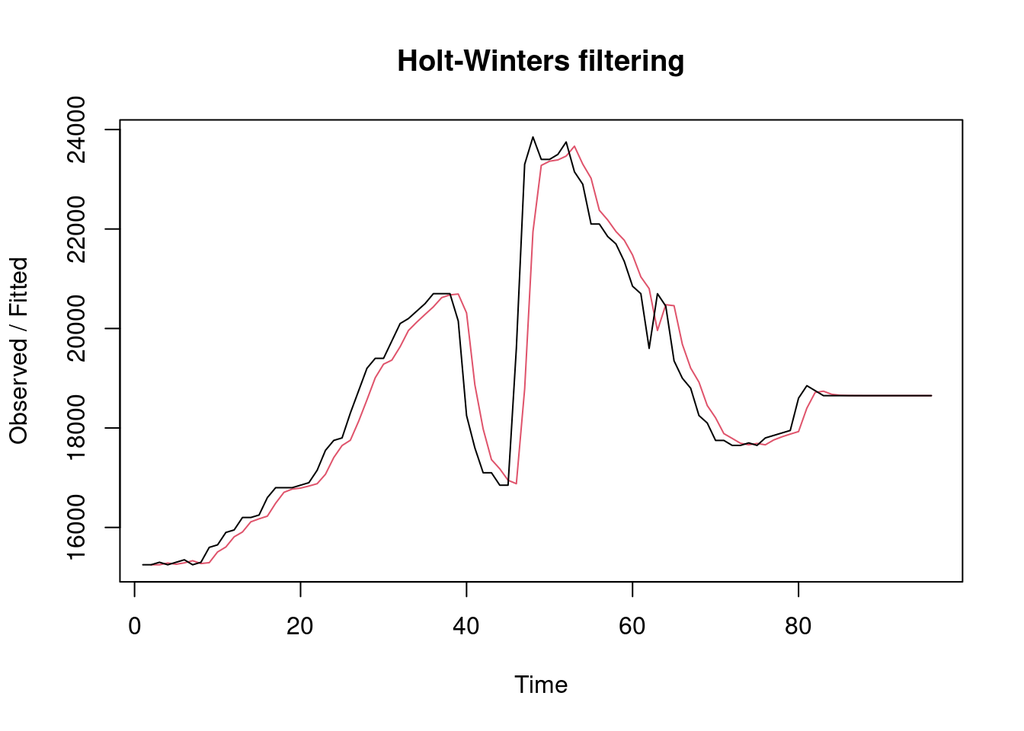

```r
ses2<- HoltWinters(train.ts, gamma = FALSE, beta = FALSE, alpha = 0.7)
plot(ses2)
```

```r
#ramalan
ramalan2<- forecast(ses2, h=24)
ramalan2
```

```
##     Point Forecast    Lo 80    Hi 80    Lo 95    Hi 95
##  97          18650 17725.89 19574.11 17236.70 20063.30
##  98          18650 17521.99 19778.01 16924.85 20375.15
##  99          18650 17349.67 19950.33 16661.31 20638.69
## 100          18650 17197.65 20102.35 16428.83 20871.17
## 101          18650 17060.11 20239.89 16218.47 21081.53
## 102          18650 16933.55 20366.45 16024.92 21275.08
## 103          18650 16815.70 20484.30 15844.68 21455.32
## 104          18650 16704.98 20595.02 15675.35 21624.65
## 105          18650 16600.23 20699.77 15515.15 21784.85
## 106          18650 16500.59 20799.41 15362.75 21937.25
## 107          18650 16405.36 20894.64 15217.11 22082.89
## 108          18650 16314.00 20986.00 15077.40 22222.60
## 109          18650 16226.09 21073.91 14942.96 22357.04
## 110          18650 16141.26 21158.74 14813.22 22486.78
## 111          18650 16059.21 21240.79 14687.72 22612.28
## 112          18650 15979.67 21320.33 14566.08 22733.92
## 113          18650 15902.44 21397.56 14447.96 22852.04
## 114          18650 15827.32 21472.68 14333.08 22966.92
## 115          18650 15754.14 21545.86 14221.17 23078.83
## 116          18650 15682.77 21617.23 14112.02 23187.98
## 117          18650 15613.08 21686.92 14005.43 23294.57
## 118          18650 15544.95 21755.05 13901.24 23398.76
## 119          18650 15478.28 21821.72 13799.28 23500.72
## 120          18650 15412.99 21887.01 13699.42 23600.58
```

Fungsi `HoltWinters` memiliki argumen yang sama dengan fungsi `ses()` . Argumen-argumen kedua fungsi dapat dilihat lebih lanjut dengan `?ses()` atau `?HoltWinters` .

Nilai parameter $\alpha$ dari kedua fungsi dapat dioptimalkan menyesuaikan dari *error*-nya paling minimumnya. Caranya adalah dengan membuat parameter $\alpha =$ `NULL` .

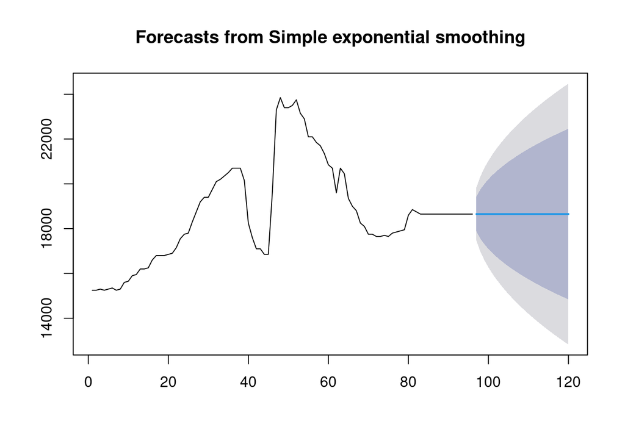

```r
#SES
ses.opt <- ses(train.ts, h = 24, alpha = NULL)
plot(ses.opt)
```

```r
ses.opt
```

```
##     Point Forecast    Lo 80    Hi 80    Lo 95    Hi 95
##  97          18650 17872.32 19427.68 17460.64 19839.36
##  98          18650 17550.25 19749.75 16968.08 20331.92
##  99          18650 17303.11 19996.89 16590.11 20709.89
## 100          18650 17094.76 20205.24 16271.47 21028.53
## 101          18650 16911.20 20388.80 15990.73 21309.27
## 102          18650 16745.25 20554.75 15736.93 21563.07
## 103          18650 16592.63 20707.37 15503.53 21796.47
## 104          18650 16450.59 20849.41 15286.29 22013.71
## 105          18650 16317.17 20982.83 15082.25 22217.75
## 106          18650 16190.99 21109.01 14889.27 22410.73
## 107          18650 16070.97 21229.03 14705.71 22594.29
## 108          18650 15956.29 21343.71 14530.33 22769.67
## 109          18650 15846.30 21453.70 14362.11 22937.89
## 110          18650 15740.47 21559.53 14200.25 23099.75
## 111          18650 15638.35 21661.65 14044.08 23255.92
## 112          18650 15539.58 21760.42 13893.02 23406.98
## 113          18650 15443.85 21856.15 13746.62 23553.38
## 114          18650 15350.90 21949.10 13604.47 23695.53
## 115          18650 15260.50 22039.50 13466.21 23833.79
## 116          18650 15172.45 22127.55 13331.55 23968.45
## 117          18650 15086.57 22213.43 13200.21 24099.79
## 118          18650 15002.72 22297.28 13071.96 24228.04
## 119          18650 14920.75 22379.25 12946.60 24353.40
## 120          18650 14840.54 22459.46 12823.93 24476.07
```

```r
#Lamda Optimum Holt Winter
sesopt<- HoltWinters(train.ts, gamma = FALSE, beta = FALSE,alpha = NULL)
sesopt
```

```
## Holt-Winters exponential smoothing without trend and without seasonal component.
##
## Call:
## HoltWinters(x = train.ts, alpha = NULL, beta = FALSE, gamma = FALSE)
##
## Smoothing parameters:
##  alpha: 0.9999267
##  beta : FALSE
##  gamma: FALSE
##
## Coefficients:
##    [,1]
## a 18650
```

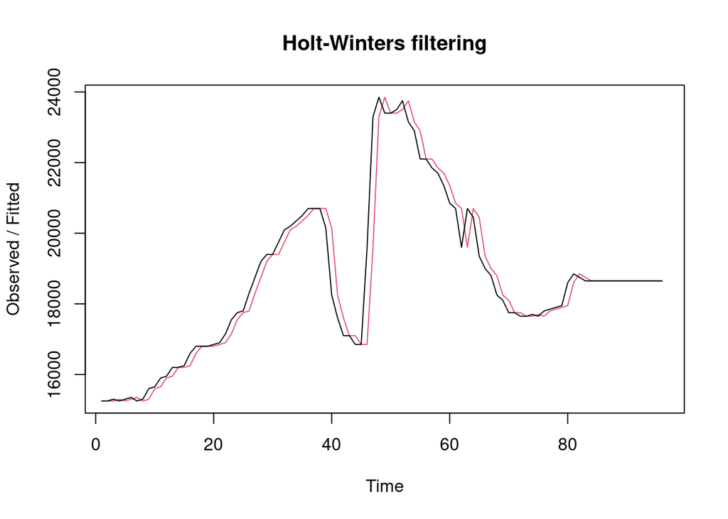

```r
plot(sesopt)
```

```r
#ramalan
ramalanopt<- forecast(sesopt, h=24)
ramalanopt
```

```
##     Point Forecast    Lo 80    Hi 80    Lo 95    Hi 95
##  97          18650 17873.99 19426.01 17463.20 19836.80
##  98          18650 17552.60 19747.40 16971.67 20328.33
##  99          18650 17305.98 19994.02 16594.50 20705.50
## 100          18650 17098.07 20201.93 16276.53 21023.47
## 101          18650 16914.90 20385.10 15996.39 21303.61
## 102          18650 16749.30 20550.70 15743.12 21556.88
## 103          18650 16597.01 20702.99 15510.22 21789.78
## 104          18650 16455.26 20844.74 15293.44 22006.56
## 105          18650 16322.13 20977.87 15089.83 22210.17
## 106          18650 16196.21 21103.79 14897.26 22402.74
## 107          18650 16076.45 21223.55 14714.09 22585.91
## 108          18650 15962.01 21337.99 14539.08 22760.92
## 109          18650 15852.26 21447.74 14371.22 22928.78
## 110          18650 15746.65 21553.35 14209.70 23090.30
## 111          18650 15644.74 21655.26 14053.86 23246.14
## 112          18650 15546.19 21753.81 13903.13 23396.87
## 113          18650 15450.66 21849.34 13757.04 23542.96
## 114          18650 15357.91 21942.09 13615.18 23684.82
## 115          18650 15267.70 22032.30 13477.22 23822.78
## 116          18650 15179.83 22120.17 13342.84 23957.16
## 117          18650 15094.14 22205.86 13211.78 24088.22
## 118          18650 15010.46 22289.54 13083.81 24216.19
## 119          18650 14928.66 22371.34 12958.71 24341.29
## 120          18650 14848.63 22451.37 12836.30 24463.70
```

## 4.3 Akurasi Data Latih

Perhitungan akurasi data dapat dilakukan dengan cara langsung maupun manual. Secara langsung, nilai akurasi dapat diambil dari objek yang tersimpan pada hasil SES, yaitu *sum of squared errors* (SSE). Nilai akurasi lain dapat dihitung pula dari nilai SSE tersebut.

```r
#Keakuratan Metode
#Pada data training
SSE1<-ses1$SSE
MSE1<-ses1$SSE/length(train.ts)
RMSE1<-sqrt(MSE1)

akurasi1 <- matrix(c(SSE1,MSE1,RMSE1))
row.names(akurasi1)<- c("SSE", "MSE", "RMSE")
colnames(akurasi1) <- c("Akurasi lamda=0.2")
akurasi1
```

```
##      Akurasi lamda=0.2
## SSE       1.504519e+08
## MSE       1.567208e+06
## RMSE      1.251882e+03
```

```r
SSE2<-ses2$SSE
MSE2<-ses2$SSE/length(train.ts)
RMSE2<-sqrt(MSE2)

akurasi2 <- matrix(c(SSE2,MSE2,RMSE2))
row.names(akurasi2)<- c("SSE", "MSE", "RMSE")
colnames(akurasi2) <- c("Akurasi lamda=0.7")
akurasi2
```

```
##      Akurasi lamda=0.7
## SSE       4.912468e+07
## MSE       5.117155e+05
## RMSE      7.153429e+02
```

```r
#Cara Manual
fitted1<-ramalan1$fitted
sisaan1<-ramalan1$residuals
head(sisaan1)
```

```
## Time Series:
## Start = 1
## End = 6
## Frequency = 1
## [1]    NA   0.0  50.0 -10.0  42.0  83.6
```

```r
resid1<-training$Minyak_Goreng-ramalan1$fitted
head(resid1)
```

```
## Time Series:
## Start = 1
## End = 6
## Frequency = 1
## [1]    NA   0.0  50.0 -10.0  42.0  83.6
```

```r
#Cara Manual
SSE.1=sum(sisaan1[2:length(train.ts)]^2)
SSE.1
```

```
## [1] 150451928
```

```r
MSE.1 = SSE.1/length(train.ts)
MSE.1
```

```
## [1] 1567208
```

```r
MAPE.1 = sum(abs(sisaan1[2:length(train.ts)]/train.ts[2:length(train.ts)])*
               100)/length(train.ts)
MAPE.1
```

```
## [1] 4.508087
```

```r
akurasi.1 <- matrix(c(SSE.1,MSE.1,MAPE.1))
row.names(akurasi.1)<- c("SSE", "MSE", "MAPE")
colnames(akurasi.1) <- c("Akurasi lamda=0.2")
akurasi.1
```

```
##      Akurasi lamda=0.2
## SSE       1.504519e+08
## MSE       1.567208e+06
## MAPE      4.508087e+00
```

```r
fitted2<-ramalan2$fitted
sisaan2<-ramalan2$residuals
head(sisaan2)
```

```
## Time Series:
## Start = 1
## End = 6
## Frequency = 1
## [1]     NA   0.00  50.00 -35.00  39.50  61.85
```

```r
resid2<-training$Minyak_Goreng-ramalan2$fitted
head(resid2)
```

```
## Time Series:
## Start = 1
## End = 6
## Frequency = 1
## [1]     NA   0.00  50.00 -35.00  39.50  61.85
```

```r
SSE.2=sum(sisaan2[2:length(train.ts)]^2)
SSE.2
```

```
## [1] 49124683
```

```r
MSE.2 = SSE.2/length(train.ts)
MSE.2
```

```
## [1] 511715.5
```

```r
MAPE.2 = sum(abs(sisaan2[2:length(train.ts)]/train.ts[2:length(train.ts)])*
               100)/length(train.ts)
MAPE.2
```

```
## [1] 1.854776
```

```r
akurasi.2 <- matrix(c(SSE.2,MSE.2,MAPE.2))
row.names(akurasi.2)<- c("SSE", "MSE", "MAPE")
colnames(akurasi.2) <- c("Akurasi lamda=0.7")
akurasi.2
```

```
##      Akurasi lamda=0.7
## SSE       4.912468e+07
## MSE       5.117155e+05
## MAPE      1.854776e+00
```

# 5 Akurasi Data Uji

Akurasi data uji dapat dihitung dengan cara yang hampir sama dengan perhitungan akurasi data latih.

```r
selisih1<-ramalan1$mean-testing$Minyak_Goreng
SSEtesting1<-sum(selisih1^2)
MSEtesting1<-SSEtesting1/length(testing)

selisih2<-ramalan2$mean-testing$Minyak_Goreng
SSEtesting2<-sum(selisih2^2)
MSEtesting2<-SSEtesting2/length(testing)

selisihopt<-ramalanopt$mean-testing$Minyak_Goreng
SSEtestingopt<-sum(selisihopt^2)
MSEtestingopt<-SSEtestingopt/length(testing)

akurasitesting1 <- matrix(c(SSEtesting1,SSEtesting2,SSEtestingopt))
row.names(akurasitesting1)<- c("SSE1", "SSE2", "SSEopt")
akurasitesting1
```

```
##            [,1]
## SSE1   260830.5
## SSE2   215000.0
## SSEopt 215000.0
```

```r
akurasitesting2 <- matrix(c(MSEtesting1,MSEtesting2,MSEtestingopt))
row.names(akurasitesting2)<- c("MSE1", "MSE2", "MSEopt")
akurasitesting2
```

```
##            [,1]
## MSE1   130415.2
## MSE2   107500.0
## MSEopt 107500.0
```

```r
accuracy(ramalanopt,testing$Minyak_Goreng)
```

```
##                    ME      RMSE       MAE       MPE      MAPE      MASE
## Training set 35.79210 603.38832 286.33122 0.1669219 1.4555791 1.0000539
## Test set     66.66667  94.64847  91.66667 0.3548957 0.4896676 0.3201593
##                   ACF1
## Training set 0.4632068
## Test set            NA
```